# An Activity Classification Scheme Using The Random Forest Algorithm

Niyas Madappattu Alikutty

27 September 2015

A classification scheme is developed using the Random Forest algorithm of R to predict the Class of activity.

## Loading and Cleaning Data

Loading the Data obatined as Data and summary of the data was examined.

```r
Data<-read.csv("pml-training.csv", header=T, sep="," )
#unique(Data$num_window)
Data<-Data[order(Data$num_window),]
#summary(Data)
```

The Summary of the data indicates coloumns with more than 90% of the data missing from some coloumns. On closer examination of these coloumns and data indicates these are maximum, minimum, standard deviation, etc for each num_window. This data is also incomplete.

As more than 90% percent of the data is missing, these colloumns are dropped. These data can easil be recreated from the other coloumns of the data.

```r
#Removing coloumns with NAs and black spaces, these are coloumns which are mean, max, var etc.
# these are coloumns that can be recreated from the Data3
Data[Data==" "] <- NA
Data<-Data[, colSums(is.na(Data))<nrow(Data)*.7]
Data<-Data[, colSums(Data=="")<nrow(Data)*.7]
#summary(Data)
Data3<-Data[,-c(1:7)]
names(Data3)
```

```
##  [1] "roll_belt"            "pitch_belt"           "yaw_belt"
##  [4] "total_accel_belt"     "gyros_belt_x"         "gyros_belt_y"
##  [7] "gyros_belt_z"         "accel_belt_x"         "accel_belt_y"
## [10] "accel_belt_z"         "magnet_belt_x"        "magnet_belt_y"
## [13] "magnet_belt_z"        "roll_arm"             "pitch_arm"
## [16] "yaw_arm"              "total_accel_arm"      "gyros_arm_x"
## [19] "gyros_arm_y"          "gyros_arm_z"          "accel_arm_x"
## [22] "accel_arm_y"          "accel_arm_z"          "magnet_arm_x"
## [25] "magnet_arm_y"         "magnet_arm_z"         "roll_dumbbell"
## [28] "pitch_dumbbell"       "yaw_dumbbell"         "total_accel_dumbbell"
## [31] "gyros_dumbbell_x"     "gyros_dumbbell_y"     "gyros_dumbbell_z"
## [34] "accel_dumbbell_x"     "accel_dumbbell_y"     "accel_dumbbell_z"
## [37] "magnet_dumbbell_x"    "magnet_dumbbell_y"    "magnet_dumbbell_z"
## [40] "roll_forearm"         "pitch_forearm"        "yaw_forearm"
## [43] "total_accel_forearm"  "gyros_forearm_x"      "gyros_forearm_y"
## [46] "gyros_forearm_z"      "accel_forearm_x"      "accel_forearm_y"
## [49] "accel_forearm_z"      "magnet_forearm_x"     "magnet_forearm_y"
## [52] "magnet_forearm_z"     "classe"
```

### Training and Testing Data set

A training and testing data set is created with 60% of the data randomly selected from the Data3, the rest are used for testing.

```r
#creating training and testing data set...
set.seed(1)
train=sample(1:nrow(Data3), nrow(Data3)*.6)
training<-Data3[train,]
testing<-Data3[-train,]
```

# Exploring the data

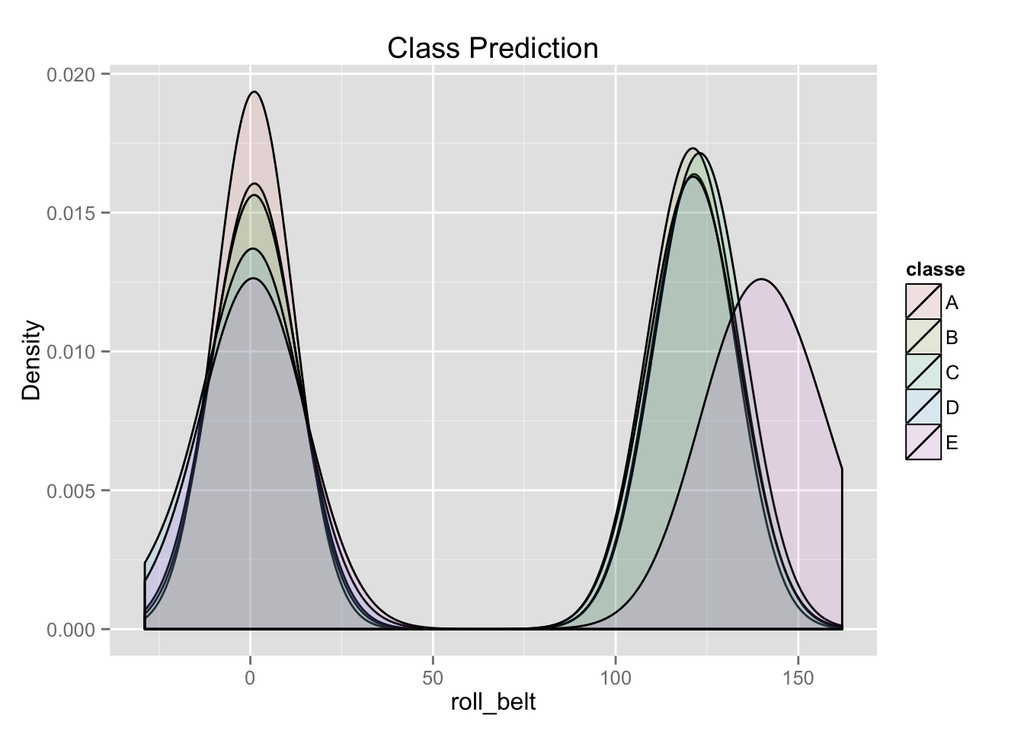

```r
library(ggplot2)
p=ggplot(training)
p=p+geom_density(aes(x=roll_belt,fill=classe), alpha=0.1)
p=p+xlab('roll_belt')
p=p+ylab('Density')
p=p+ggtitle('Class Prediction')
p
```

While expoloring the data using various plots using predictors, it clear any other classification scheme will be difficult due to large number of predictors involved (52). So, the Random Forest algoirthm is used for this classification.Here, doParallel is used to multiple core available in the system.

### Random Forest in Parallel

doParallel package is used run randomForest in parallel process. The Random Forest algorithm are ideal for handling data with high dimensions. The Number of trees created are 900.

```r
library(doParallel)# Parallelising using doParallel package for any
library(randomForest)
cl <- makeCluster(3)# Using 3 Cores
registerDoParallel(cl)
set.seed(1)
x<-training[-ncol(training)]
y<-training$classe
rf.exercise <- foreach(ntree=rep(150,6), .combine=randomForest::combine,.packages='randomForest') %dopar% {
  randomForest(x,y, ntree=ntree, importance = T)
}
stopCluster(cl)
print(rf.exercise)
```

```
##
## Call:
##  randomForest(x = x, y = y, ntree = ntree, importance = T)
##                Type of random forest: classification
##                      Number of trees: 900
## No. of variables tried at each split: 7
```

### Variable importance and Accuracy Measurment

```r
 rf.imp<-importance(rf.exercise)
 rf.imp[order(rf.imp[,6], decreasing=T),][1:15,]#15 predictors with importance
```

```
##                           A        B         C         D         E
## yaw_belt          25.426747 23.91118 22.604544 25.426734 17.873606
## roll_belt         21.067150 25.96965 25.981877 25.143984 22.586895
## magnet_dumbbell_z 22.688098 20.32801 25.087145 21.097774 18.711142
## pitch_belt        17.438005 25.64208 20.573814 17.959753 17.811452
## pitch_forearm     17.441968 19.26252 21.785597 18.630255 18.282060
## magnet_dumbbell_y 18.192446 18.90457 22.096289 17.837001 16.182994
## magnet_forearm_z  13.274120 15.87667 13.990769 14.691408 14.246078
## accel_dumbbell_y  14.019888 14.98992 17.113330 14.800555 15.035243
## gyros_dumbbell_x   9.547676 14.11967 12.520696 11.111697 10.434330
## gyros_arm_y       10.017129 14.84528 11.964173 13.563858 10.987077
## roll_arm          11.717266 16.12187 15.402591 15.063411 11.172498
## magnet_belt_x     10.186490 15.08445 13.238748 11.497942 13.332969
## accel_dumbbell_z  12.109696 14.94426 14.087615 13.928880 15.570444
## gyros_dumbbell_z   9.460112 12.10303  9.691305  9.241873  8.697242
## accel_forearm_z    9.305232 12.91931 13.626831 12.899871 12.986725
##                   MeanDecreaseAccuracy MeanDecreaseGini
## yaw_belt                      34.77483        523.63667
## roll_belt                     30.34450        760.07334
## magnet_dumbbell_z             26.79808        450.17103
## pitch_belt                    26.46360        427.53665
## pitch_forearm                 23.11804        480.49804
## magnet_dumbbell_y             21.58098        390.32562
## magnet_forearm_z              19.90553        162.94067
## accel_dumbbell_y              18.91573        258.24276
## gyros_dumbbell_x              18.74851         77.36964
## gyros_arm_y                   18.67570         83.41660
## roll_arm                      18.22575        187.29138
## magnet_belt_x                 18.06247        150.16447
## accel_dumbbell_z              18.04779        200.18773
## gyros_dumbbell_z              17.22888         51.52380
## accel_forearm_z               16.67280        148.19385
```

The confusion matrix is used to obtain the accuracy of the prediction. The predict function is used to make prediction on the testing dataset. The accuracy using the confusion matrix gives more than 99% accuracy and 95% confidence interval is within 99% accuracy.

```r
#confusion matrix
library(MASS)
library(caret)
 #testing data set
Predicttrain<-predict(rf.exercise, newdata=training)
confusionMatrix(Predicttrain, training$classe)
```

```
## Confusion Matrix and Statistics
##
##           Reference
## Prediction    A    B    C    D    E
##          A 3361    0    0    0    0
##          B    0 2252    0    0    0
##          C    0    0 2035    0    0
##          D    0    0    0 1942    0
##          E    0    0    0    0 2183
##
## Overall Statistics
##
##                Accuracy : 1
##                  95% CI : (0.9997, 1)
##     No Information Rate : 0.2855
##     P-Value [Acc > NIR] : < 2.2e-16
##
##                   Kappa : 1
##  Mcnemar's Test P-Value : NA
##
## Statistics by Class:
##
##                      Class: A Class: B Class: C Class: D Class: E
## Sensitivity            1.0000   1.0000   1.0000    1.000   1.0000
## Specificity            1.0000   1.0000   1.0000    1.000   1.0000
## Pos Pred Value         1.0000   1.0000   1.0000    1.000   1.0000
## Neg Pred Value         1.0000   1.0000   1.0000    1.000   1.0000
## Prevalence             0.2855   0.1913   0.1729    0.165   0.1854
## Detection Rate         0.2855   0.1913   0.1729    0.165   0.1854
## Detection Prevalence   0.2855   0.1913   0.1729    0.165   0.1854
## Balanced Accuracy      1.0000   1.0000   1.0000    1.000   1.0000
```

```r
#testing data set
Prediction<-predict(rf.exercise, newdata=testing)
confusionMatrix(Prediction, testing$classe)
```

```
## Confusion Matrix and Statistics
##
##           Reference
## Prediction    A    B    C    D    E
##          A 2218   15    0    0    0
##          B    0 1528   10    0    0
##          C    0    2 1373   11    0
##          D    0    0    4 1263    0
##          E    1    0    0    0 1424
##
## Overall Statistics
##
##                Accuracy : 0.9945
##                  95% CI : (0.9926, 0.996)
##     No Information Rate : 0.2827
##     P-Value [Acc > NIR] : < 2.2e-16
##
##                   Kappa : 0.9931
##  Mcnemar's Test P-Value : NA
##
## Statistics by Class:
##
##                      Class: A Class: B Class: C Class: D Class: E
## Sensitivity            0.9995   0.9890   0.9899   0.9914   1.0000
## Specificity            0.9973   0.9984   0.9980   0.9994   0.9998
## Pos Pred Value         0.9933   0.9935   0.9906   0.9968   0.9993
## Neg Pred Value         0.9998   0.9973   0.9978   0.9983   1.0000
## Prevalence             0.2827   0.1968   0.1767   0.1623   0.1814
## Detection Rate         0.2826   0.1947   0.1749   0.1609   0.1814
## Detection Prevalence   0.2845   0.1959   0.1766   0.1614   0.1816
## Balanced Accuracy      0.9984   0.9937   0.9939   0.9954   0.9999
```

[figure not shown]

```r
varImpPlot(rf.exercise, n.var=12, bg="red", main="Variable Importance")
```

### Testing with external data set

```r
Data_finaltest<-read.csv("pml-testing.csv", header=T, sep="," )
#Data_finaltest<-Data_finaltest[order(Data_finaltest$num_window),]
#Removing coloumns with NAs and black spaces, these are coloumns which are mean, max, var etc.
# these are coloumns that can be recreated from the Data3
Data_finaltest[Data_finaltest==" "] <- NA
Data_finaltest<-Data_finaltest[, colSums(is.na(Data_finaltest))<nrow(Data_finaltest)*.7]
Data_finaltest<-Data_finaltest[, colSums(Data_finaltest=="")<nrow(Data_finaltest)*.7]
#summary(Data)
Data3_finaltest<-Data_finaltest[,-c(1:7)]
Prediction<-predict(rf.exercise, newdata=Data3_finaltest)
Prediction
```

```
##  1  2  3  4  5  6  7  8  9 10 11 12 13 14 15 16 17 18 19 20
##  B  A  B  A  A  E  D  B  A  A  B  C  B  A  E  E  A  B  B  B
## Levels: A B C D E
```

```r
pml_write_files = function(x){
  n = length(x)
  for(i in 1:n){
    filename = paste0("problem_id_",i,".txt")
    write.table(x[i],file=filename,quote=FALSE,row.names=FALSE,col.names=FALSE)
  }
}

pml_write_files(Prediction)
```

### Conclusion

A classification scheme was developed to predict the class of activity the participant is performing. The classification scheme predicts the activity on the testing set with more than 99% accurarcy.